# Pertemuan 5

Megawati Roito Panjaitan

2023-09-26

## Library

```r
library(ggplot2)
library(tsibble)
library(tseries)
library(MASS)
```

## Impor Data

```r
data <- rio::import("https://raw.githubusercontent.com/panjaitanroito/Praktikum-MPDW/main/Pertemuan%205/data1.csv")
str(data)
```

```
## 'data.frame':    240 obs. of  2 variables:
##  $ Period: int  1 2 3 4 5 6 7 8 9 10 ...
##  $ Value : int  268044 272020 275192 271046 271394 273422 272630 272918 277548 276927 ...
```

```r
stas <-ts(data$Value)
```

### Plot Time Series

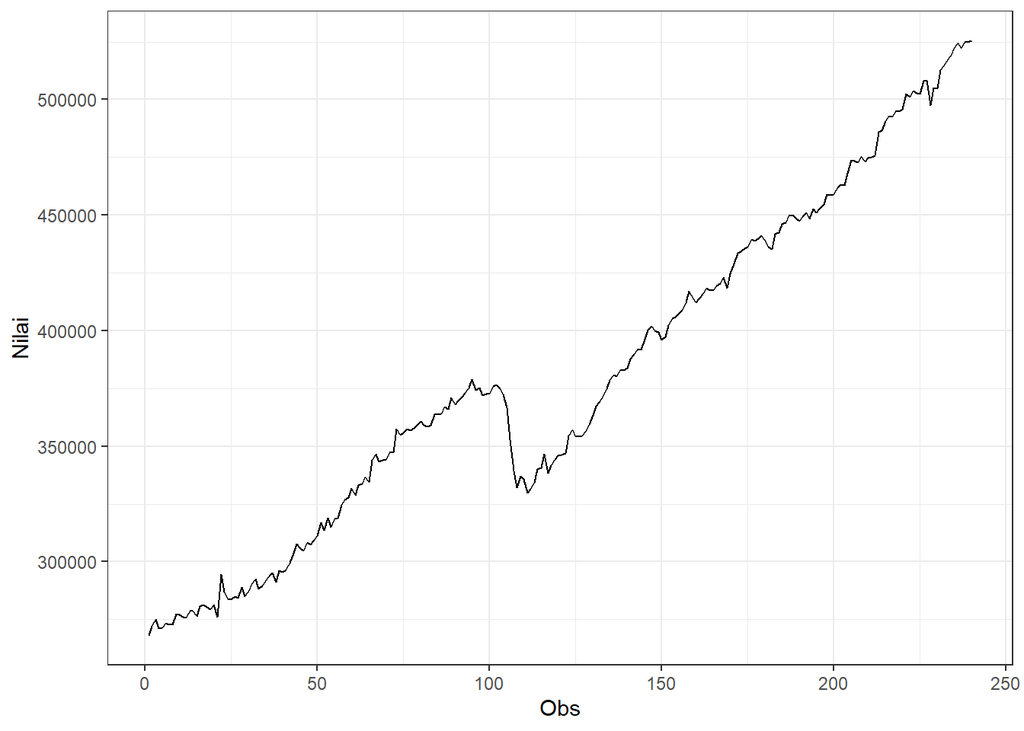

```r
plot_stas <- stas |> as_tsibble() |>
  ggplot(aes(x = index, y = value)) + geom_line() + theme_bw() +
  xlab("Obs") + ylab("Nilai")
plot_stas
```

```r
mean(stas)
```

```
## [1] 381525.6
```

Plot deret waktu di atas menunjukkan bahwa data tidak stasioner dalam rataan, ditandai dengan data yang memiliki pola tren.

### Plot ACF

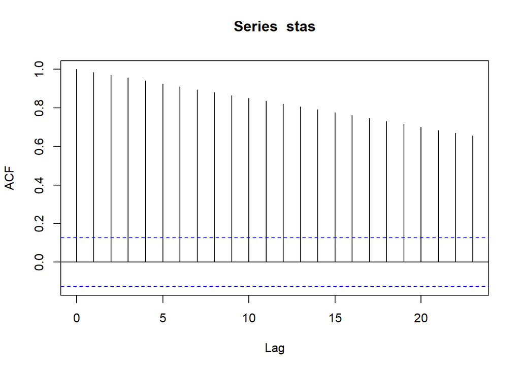

```r
acf(stas)
```

Berdasarkan plot ACF, terlihat bahwa plot ACF pada data tersebut cenderung tails off slowly sehingga berdasarkan plot ACF data tidak stasioner dalam rataan.

### Plot ADF

```r
tseries::adf.test(stas)
```

```
##
##  Augmented Dickey-Fuller Test
##
## data:  stas
## Dickey-Fuller = -1.721, Lag order = 6, p-value = 0.6932
## alternative hypothesis: stationary
```

$H_0$ : Data tidak stasioner dalam rataan

$H_1$ : Data stasioner dalam rataan

Berdasarkan uji ADF tersebut, didapat p-value sebesar 0.6932 yang lebih besar dari taraf nyata 5% sehingga tak tolak H0 dan menandakan bahwa data tidak stasioner dalam rataan. Hal ini sesuai dengan hasil eksplorasi menggunakan plot time series dan plot ACF.

### Plot Boxcox

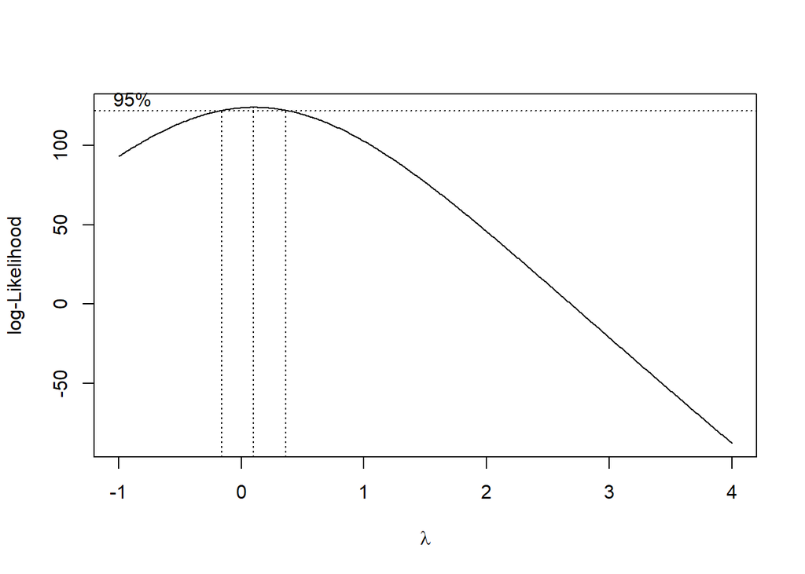

```r
index <- seq(1:240)
bc = boxcox(stas~index, lambda = seq(-1,4,by=0.01))
```

```r
#Nilai Rounded Lambda
lambda <- bc$x[which.max(bc$y)]
lambda
```

```
## [1] 0.1
```

```r
#SK
bc$x[bc$y > max(bc$y) - 1/2 * qchisq(.95,1)]
```

```
##  [1] -0.15 -0.14 -0.13 -0.12 -0.11 -0.10 -0.09 -0.08 -0.07 -0.06 -0.05 -0.04
## [13] -0.03 -0.02 -0.01  0.00  0.01  0.02  0.03  0.04  0.05  0.06  0.07  0.08
## [25]  0.09  0.10  0.11  0.12  0.13  0.14  0.15  0.16  0.17  0.18  0.19  0.20
## [37]  0.21  0.22  0.23  0.24  0.25  0.26  0.27  0.28  0.29  0.30  0.31  0.32
## [49]  0.33  0.34  0.35  0.36
```

Gambar di atas menunjukkan nilai rounded value (λ) optimum sebesar 0.1 dan pada selang kepercayaan 95% nilai memiliki batas bawah -0.15 dan batas atas 0.36. Selang tersebut tidak memuat nilai satu sehingga dapat dikatakan bahwa data tidak stasioner dalam ragam.

## Partisi Data

### Bagian 1

```r
dt_stas1 <- stas[1:90] |> ts()
mean(dt_stas1)
```

```
## [1] 312784.5
```

```r
var(dt_stas1)
```

```
## [1] 1043091722
```

#### Plot Time Series

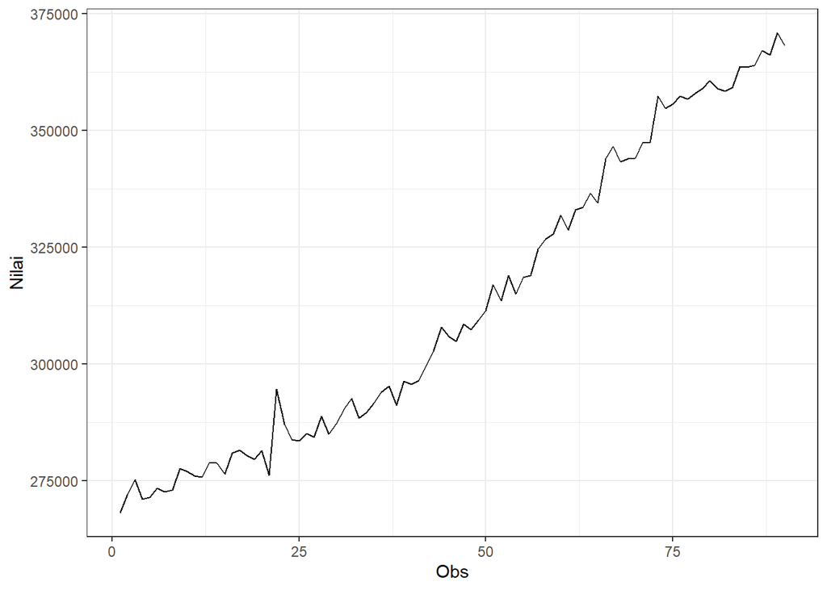

```r
dt_stas1 |> as_tsibble() |>
  ggplot(aes(x = index, y = value)) +
  geom_line() + theme_bw() +
  xlab("Obs") + ylab("Nilai")
```

Plot deret waktu di atas menunjukkan bahwa data tidak stasioner dalam rataan, ditandai dengan data berpola tren naik.

#### Plot ACF

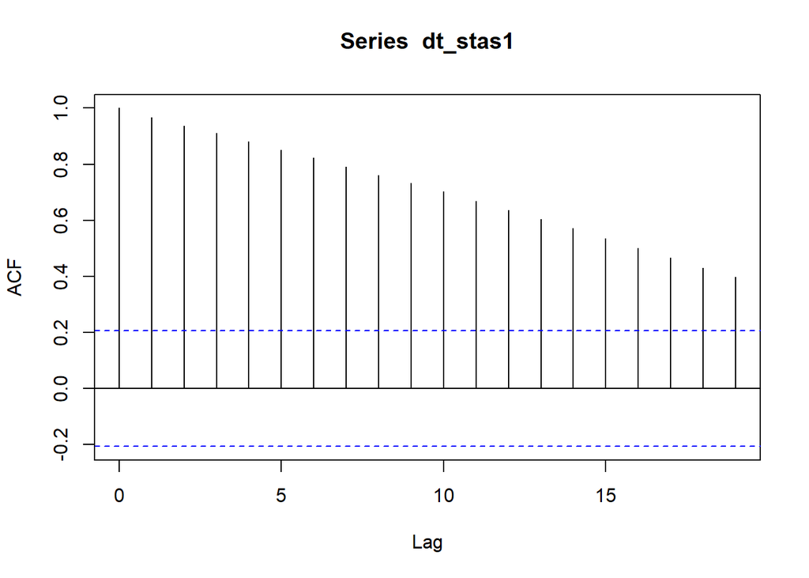

```r
acf(dt_stas1)
```

Berdasarkan plot ACF, terlihat bahwa plot ACF pada data tersebut cenderung tails off slowly sehingga berdasarkan plot ACF data tidak stasioner dalam rataan.

#### Uji ADF

```r
tseries::adf.test(dt_stas1)
```

```
##
##  Augmented Dickey-Fuller Test
##
## data:  dt_stas1
## Dickey-Fuller = -1.9316, Lag order = 4, p-value = 0.6043
## alternative hypothesis: stationary
```

$H_0$ : Data tidak stasioner dalam rataan

$H_1$ : Data stasioner dalam rataan

Berdasarkan uji ADF tersebut, didapat *p-value* sebesar 0.6043 yang lebih besar dari taraf nyata 5% sehingga rak tolak $H_0$ dan menandakan bahwa data tidak stasioner dalam rataan. Hal ini sesuai dengan hasil eksplorasi menggunakan plot time series dan plot ACF.

#### Plot Boxcox

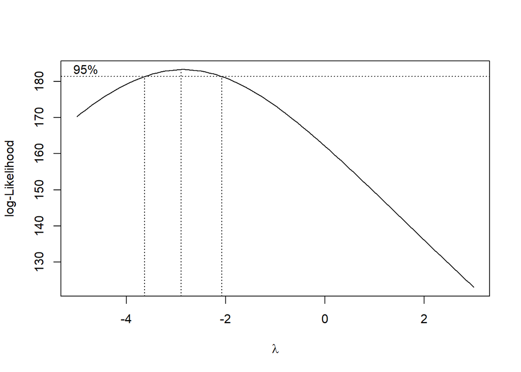

```r
index <- seq(1:90)
bc = boxcox(dt_stas1~index, lambda = seq(-5,3,by=1))
```

```r
#Nilai Rounded Lambda
lambda <- bc$x[which.max(bc$y)]
lambda
```

```
## [1] -2.89899
```

```r
#SK
bc$x[bc$y > max(bc$y) - 1/2 * qchisq(.95,1)]
```

```
##  [1] -3.626263 -3.545455 -3.464646 -3.383838 -3.303030 -3.222222 -3.141414
##  [8] -3.060606 -2.979798 -2.898990 -2.818182 -2.737374 -2.656566 -2.575758
## [15] -2.494949 -2.414141 -2.333333 -2.252525 -2.171717 -2.090909
```

Gambar di atas menunjukkan nilai rounded value (λ ) optimum sebesar -2.89899 dan pada selang kepercayaan 95% nilai memiliki batas bawah -3.626263 dan batas atas -2.090909. Selang tersebut tidak memuat nilai satu sehingga dapat dikatakan bahwa data tidak stasioner dalam ragam.

### Bagian 2

```r
dt_stas2 <- stas[1:170] |> ts()
mean(dt_stas2)
```

```
## [1] 343459.1
```

```r
var(dt_stas2)
```

```
## [1] 1963411918
```

#### Plot Time Series

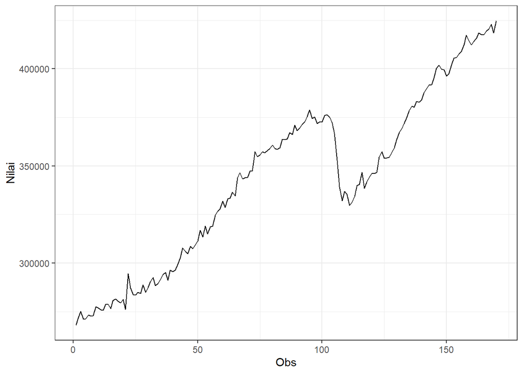

```r
dt_stas2 |> as_tsibble() |>
  ggplot(aes(x = index, y = value)) +
  geom_line() + theme_bw() +
  xlab("Obs") + ylab("Nilai")
```

Plot deret waktu di atas menunjukkan bahwa data tidak stasioner dalam rataan, ditandai dengan data yang berpola tren naik.

#### Uji ACF

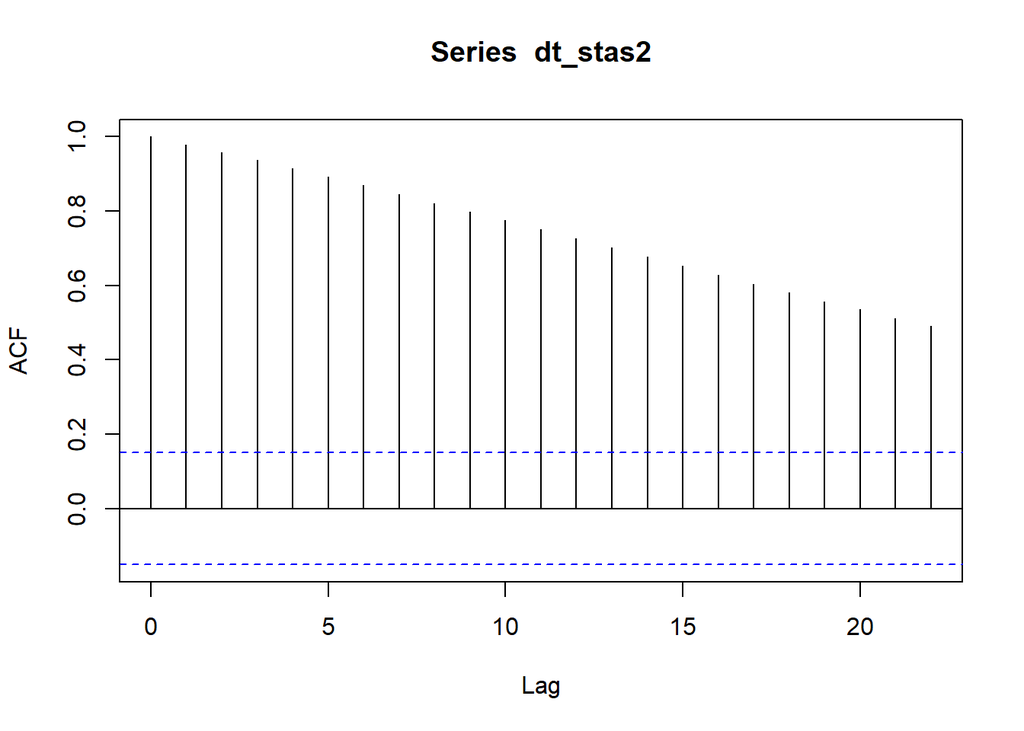

```r
acf(dt_stas2)
```

Berdasarkan plot ACF, terlihat bahwa plot ACF pada data tersebut cenderung tails off slowly sehingga dismpulkan bahwa data tidak stasioner dalam rataan.

#### Uji ADF

```r
adf.test(dt_stas2)
```

```
##
##  Augmented Dickey-Fuller Test
##
## data:  dt_stas2
## Dickey-Fuller = -1.8905, Lag order = 5, p-value = 0.622
## alternative hypothesis: stationary
```

$H_0$ : Data tidak stasioner dalam rataan

$H_1$ : Data stasioner dalam rataan

#### Plot Boxcox

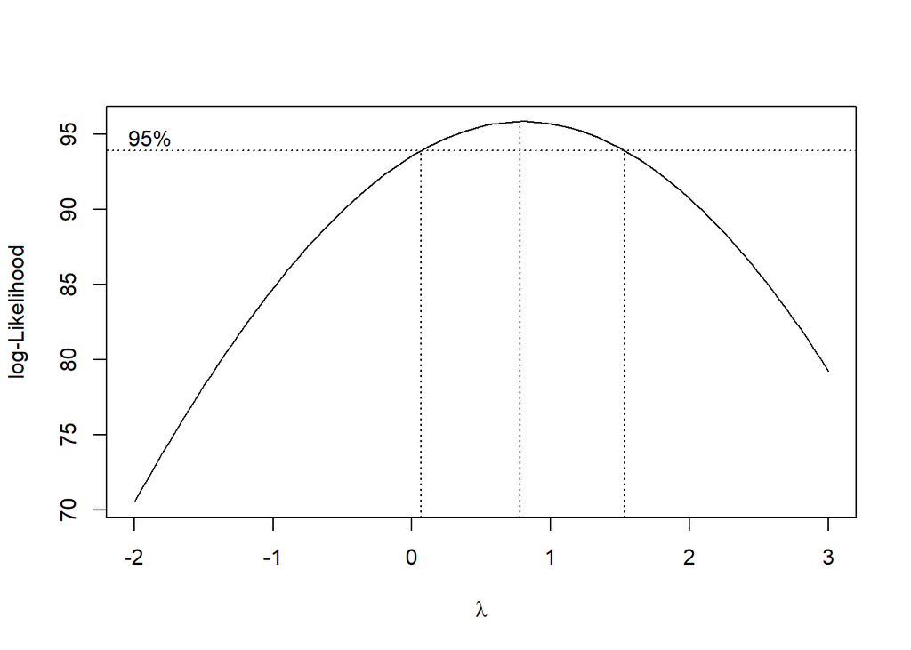

```r
index <- seq(1:170)
bc = boxcox(dt_stas2~index, lambda = seq(-2,3,by=1))
```

```r
#Nilai Rounded Lambda
lambda <- bc$x[which.max(bc$y)]
lambda
```

```
## [1] 0.7777778
```

```r
#SK
bc$x[bc$y > max(bc$y) - 1/2 * qchisq(.95,1)]
```

```
##  [1] 0.07070707 0.12121212 0.17171717 0.22222222 0.27272727 0.32323232
##  [7] 0.37373737 0.42424242 0.47474747 0.52525253 0.57575758 0.62626263
## [13] 0.67676768 0.72727273 0.77777778 0.82828283 0.87878788 0.92929293
## [19] 0.97979798 1.03030303 1.08080808 1.13131313 1.18181818 1.23232323
## [25] 1.28282828 1.33333333 1.38383838 1.43434343 1.48484848
```

Gambar di atas menunjukkan nilai rounded value (λ ) optimum sebesar 0.7777778 dan pada selang kepercayaan 95% nilai memiliki batas bawah 0.07070707 dan batas atas 1.48484848. Selang tersebut memuat nilai satu sehingga dapat dikatakan bahwa data stasioner dalam ragam.